# Punto 4 del segundo parcial

## Parcial 2, Punto 4

En este ejercicio se tendrá que analizar un dataset (inédito, no está en internet), sobre diversos parámetros determinados a partir de imágenes digitales de células de la sangre periférica, relacionadas con pacientes sanos, pacientes con leucemias agudas y pacientes con infecciones víricas.

INSERTE LA RUTA DEL DIRECTORIO DONDE SE ENCUENTRAN LOS DATOS EN LA VARIABLE `directorio`.

```r
directorio = "data"
archivo = paste(directorio, "malignant_cells2.csv", sep ='/')
```

A continuación se lee el dataset `malignant_cells2.csv`

```r
# INSERTE EL CODIGO AQUI
df = read.csv(file=archivo)
```

Puede inspeccionar el dataset utilizando `head(df)` o simplemente haciendo click en en la variable `df` en la ventana de Enviroment.

```r
dim(df)
```

```
## [1] 1000  216
```

Este dataset contiene un total de 1000 células y 216 parámetros. La columna que describe el tipo de célula es `tipoCelula`. Los tipos y el número de células por tipo se pueden conocer ejecutando:

```r
table(df$tipoCelula)
```

```
##
##  BL   N  RL
## 717 115 168
```

La siguiente figura muestra un ejemplo para cada tipo de célula analizadas.

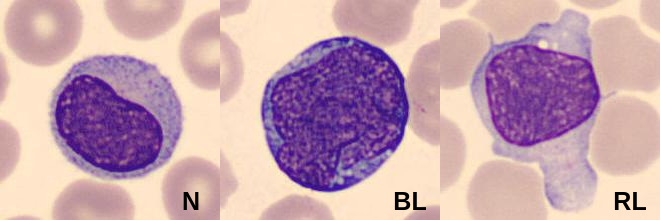

Ejemplo de las tres tipos de células analizadas: N, BL y RL.

A continuación se describen las abreviaciones de cada clase:

- N: son linfocitos normales, presentes tanto en pacientes sanos como enfermos.
- BL: son blastos un tipo de célula que aparece en la sangre periférica cuando el paciente tiene una leucemia aguda.
- RL: son linfocitos reactivos, que aparecen cuando el paciente padece una infección vírica.

El descriptor que se va a analizar cómo ejemplo es la `relación nucleo-célula`, un parámetro que se define como la relación entre el área del núcleo y el área de toda la célula. Sin embargo, **debe seleccionar el descriptor de acuerdo a sus dos últimos dígitos de su cédula** como muestra la siguiente tabla:

| Descriptor | 2 últimos dígitos de CC | Descripción |
| --- | --- | --- |
| NCellratio | Ejemplo | Relacion nucleo-celula |
| RBCproximity | 24 | Proximidad de los globulos rojos |
| Perimeter_cel | 68 | Perimetro de la celula |
| R_S1_Skewness_cel | 26 | Asimetria de la componente roja en la celula |
| G_S1_Std_cel | 73 | Desviacion estandar de la componente verde en la celula |
| Area_cel | 12 | Area de la celula |
| Pgra_R_mean_cel | 39 | media de la curva pseudo-granulometrica de la componente roja en la celula |
| EquivDiameter_nuc | 63 | Diametro equivalente del nucleo |
| G_S2_Energy_nuc | 28 | Energia (orden 2) de la componente verde del nucleo |

#### A continuación se grafica un boxplot para conocer y comparar las distribuciones del descriptor respecto a cada tipo de célula (y sus medias).

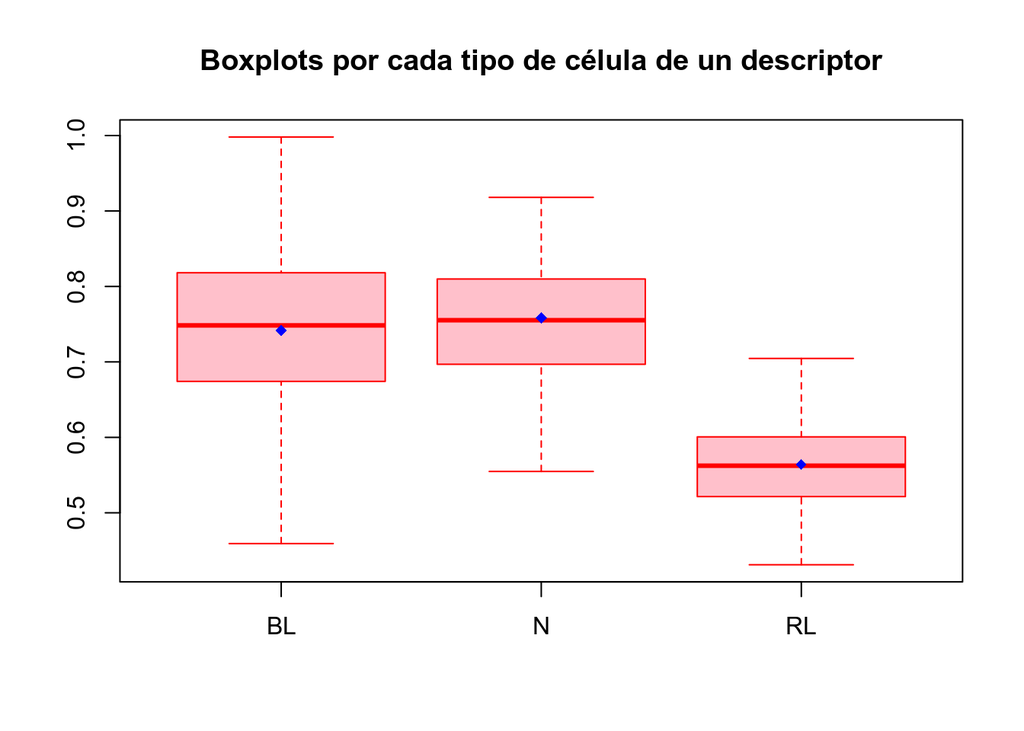

```r
descriptor =  "NCellratio"

boxplot(as.formula(paste(descriptor, '~tipoCelula')), # Descriptor vs tipoCelula para mostrar tres boxplots, x cada cel
        data=df,
        outline=FALSE, # No muestra outliers,
        main="Boxplots por cada tipo de célula de un descriptor",
        col="pink",
        border="red"
        )

means <- tapply(df[[descriptor]], df$tipoCelula,mean) #Halla las medias
points(means,col="blue",pch=18) # Grafica cada media como un punto azul
```